# R : Exploring and Visualizing Extracted Dimensions from Principal Component Algorithms

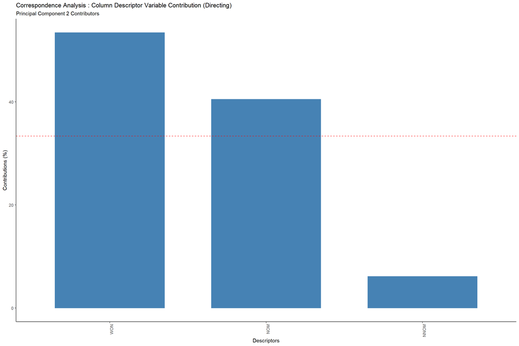

```r
##################################
# Extracting the contribution
# of the column descriptor variables
# for the the Top 2 principal component
##################################
(DR_CA_Directing_COL_PC2VariableContributors <- fviz_contrib(DR_CA_Directing,
                                                             choice = "col",
                                                             axes = 2) +
  labs(title = "Correspondence Analysis : Column Descriptor Variable Contribution (Directing)",
       subtitle = "Principal Component 2 Contributors",
       x = "Descriptors") +
  theme_classic() +
  theme(axis.text.x = element_text(angle = 90,hjust = 1)))
```

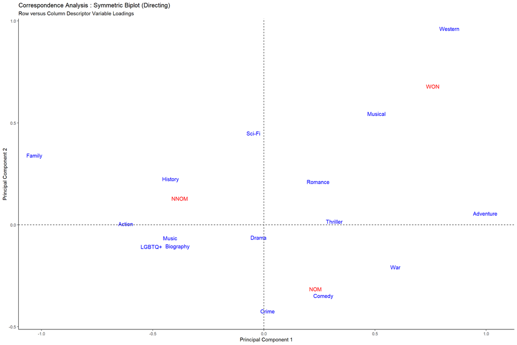

```r
##################################
# Formulating the Symmetric Biplot
# using the row and column
# descriptor variable loadings
# for the Top 1 and Top 2 principal components
##################################
(DR_CA_SymmetricBiplot <- fviz_ca_biplot(DR_CA_Directing,
              label="all",
              geom = "text",
              repel = TRUE) +
  labs(title = "Correspondence Analysis : Symmetric Biplot (Directing)",
       subtitle = "Row versus Column Descriptor Variable Loadings",
       x = "Principal Component 1",
       y = "Principal Component 2") +
  theme_classic())
```

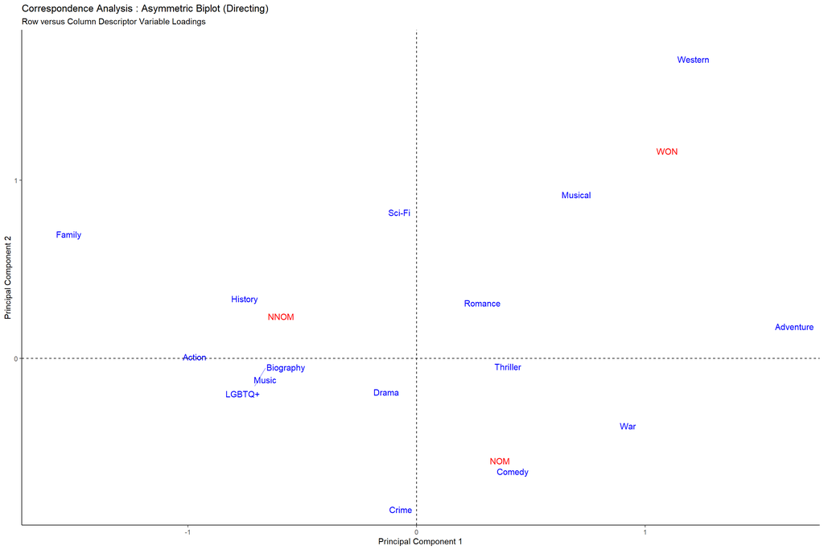

```r
##################################
# Formulating the Asymmetric Biplot
# using the row and column
# descriptor variable loadings
# for the Top 1 and Top 2 principal components
##################################
(DR_CA_SymmetricBiplot <- fviz_ca_biplot(DR_CA_Directing,
              label="all",
              geom = "text",
              repel = TRUE,
              map = "symbiplot") +
  labs(title = "Correspondence Analysis : Asymmetric Biplot (Directing)",
       subtitle = "Row versus Column Descriptor Variable Loadings",
       x = "Principal Component 1",
       y = "Principal Component 2") +
  theme_classic())
```

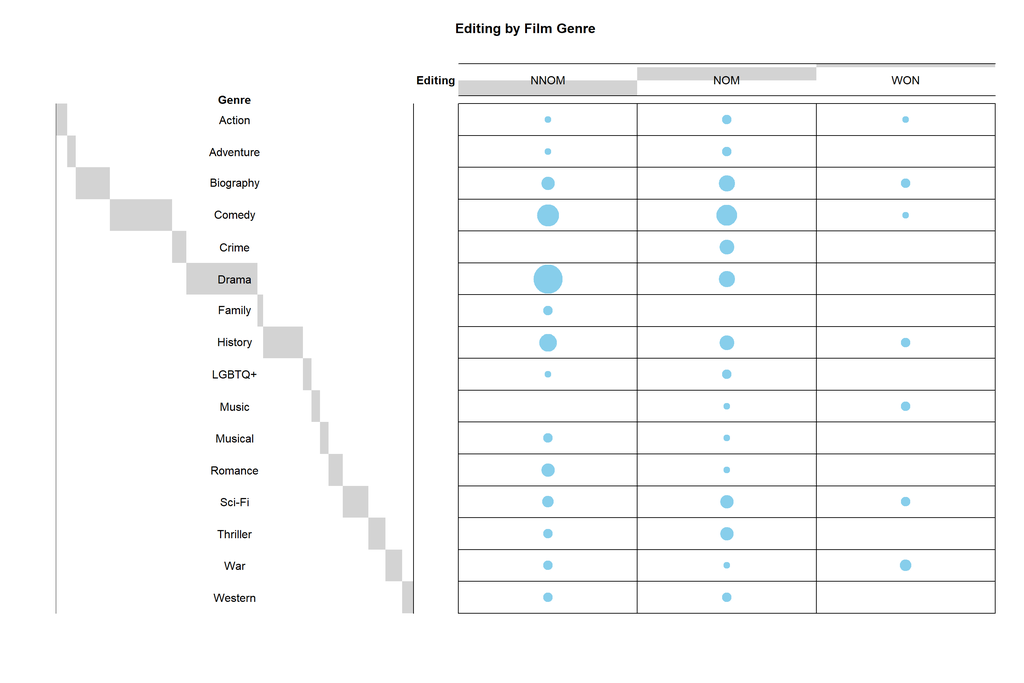

```r
##################################
# Loading dataset for Editing
##################################
SD_CA_Editing <- Oscars.CA.Editing

balloonplot(t(as.table(as.matrix(SD_CA_Editing))),
            main="Editing by Film Genre",
            xlab="Editing",
            ylab="Genre",
            label=FALSE,
            show.margins=FALSE)
```

```r
##################################
# Conducting a Chi-Square Test
##################################
(SD_CA_Editing_CHSQ <- chisq.test(SD_CA_Editing))
```

```
##
##  Pearson's Chi-squared test
##
## data:  SD_CA_Editing
## X-squared = 50.873, df = 30, p-value = 0.01005
```

```r
##################################
# Performing CA
##################################
DR_CA_Editing <- CA(SD_CA_Editing,
                           graph = FALSE)

##################################
# Obtaining the CA eigenvalues
##################################
(DR_CA_Editing_EV <- get_eigenvalue(DR_CA_Editing))
```

```
##       eigenvalue variance.percent cumulative.variance.percent
## Dim.1  0.2584184         64.00355                    64.00355
## Dim.2  0.1453380         35.99645                   100.00000
```

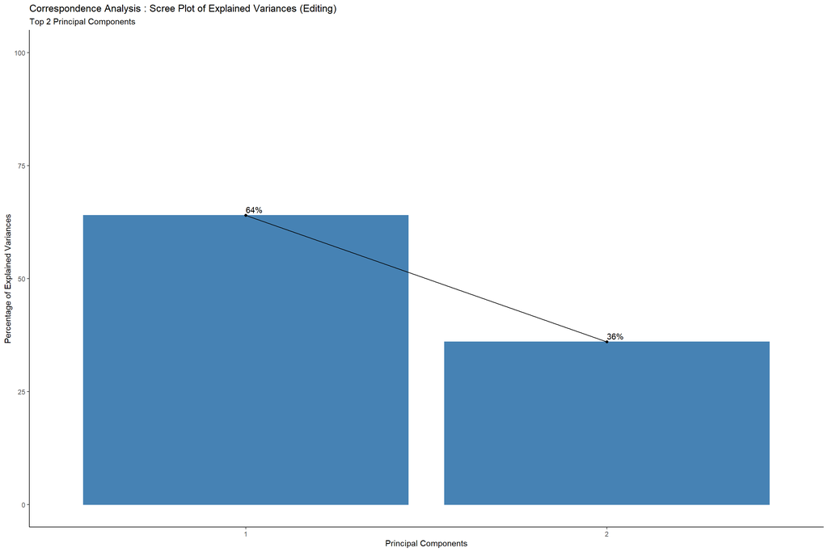

```r
##################################
# Formulating the Scree Plot
# for the variances
##################################
(DR_CA_Editing_VarianceScreePlot <- fviz_eig(DR_CA_Editing,
                                                    addlabels = TRUE,
                                                    ylim = c(0, 100),
                                                    choice = c("variance")) +
  labs(title = "Correspondence Analysis : Scree Plot of Explained Variances (Editing)",
       subtitle = "Top 2 Principal Components",
       y = "Percentage of Explained Variances",
       x = "Principal Components") +
  theme_classic())
```

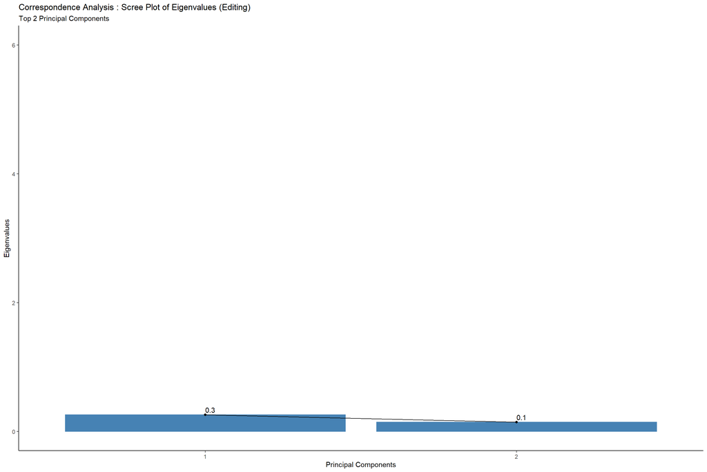

```r
##################################
# Formulating the Scree Plot
# for the eigenvalues
##################################
(DR_CA_Editing_EigenvalueScreePlot <- fviz_eig(DR_CA_Editing,
                                                      addlabels = TRUE,
                                                      ylim = c(0, 6),
                                                      choice = c("eigenvalue")) +
  labs(title = "Correspondence Analysis : Scree Plot of Eigenvalues (Editing)",
       subtitle = "Top 2 Principal Components",
       y = "Eigenvalues",
       x = "Principal Components") +
  theme_classic())
```

```r
##################################
# Extracting the CA
# results for row descriptor variables
##################################
(DR_CA_Editing_ROW <- get_ca_row(DR_CA_Editing))
```

```
## Correspondence Analysis - Results for rows
##  ===================================================
##   Name       Description
## 1 "$coord"   "Coordinates for the rows"
## 2 "$cos2"    "Cos2 for the rows"
## 3 "$contrib" "contributions of the rows"
## 4 "$inertia" "Inertia of the rows"
```

```r
##################################
# Extracting the coordinates
# representing the loadings
# for the row descriptor variabless
##################################
DR_CA_Editing_ROW$coord
```

```
##                 Dim 1       Dim 2
## Action     0.56704105 -0.13820733
## Adventure -0.16441566 -0.52858184
## Biography  0.28198554 -0.15808970
## Comedy    -0.16637971 -0.09681112
## Crime      0.08300400 -1.19003666
## Drama     -0.48111282  0.31808033
## Family    -0.65925497  0.79432780
## History    0.09450411  0.11971026
## LGBTQ+    -0.16441566 -0.52858184
## Music      1.86860879  0.29193192
## Musical   -0.41183532  0.13287298
## Romance   -0.51080318  0.39745491
## Sci-Fi     0.43078594 -0.03459231
## Thriller  -0.16441566 -0.52858184
## War        1.17478794  0.58289460
## Western   -0.28812549 -0.19785443
```

```r
##################################
# Extracting the quality of representation
# for the row descriptor variables
# on the factor map
##################################
DR_CA_Editing_ROW$cos2
```

```
##                 Dim 1       Dim 2
## Action    0.943924837 0.056075163
## Adventure 0.088217200 0.911782800
## Biography 0.760857495 0.239142505
## Comedy    0.747065329 0.252934671
## Crime     0.004841385 0.995158615
## Drama     0.695846312 0.304153688
## Family    0.407871452 0.592128548
## History   0.383939061 0.616060939
## LGBTQ+    0.088217200 0.911782800
## Music     0.976173866 0.023826134
## Musical   0.905719893 0.094280107
## Romance   0.622883592 0.377116408
## Sci-Fi    0.993593147 0.006406853
## Thriller  0.088217200 0.911782800
## War       0.802449252 0.197550748
## Western   0.679555338 0.320444662
```

```r
##################################
# Extracting the contributions
# (in percentage) of the row descriptor variables
# to the principal components
##################################
DR_CA_Editing_ROW$contrib
```

```
##                Dim 1       Dim 2
## Action     3.9499807  0.41722700
## Adventure  0.2490655  4.57715913
## Biography  2.9304944  1.63771622
## Comedy     1.8703779  1.12596125
## Crime      0.1057972 38.66704312
## Drama     17.7721450 13.81223319
## Family     2.6695792  6.89096101
## History    0.3840037  1.09557242
## LGBTQ+     0.2490655  4.57715913
## Music     32.1709592  1.39615846
## Musical    1.5626957  0.28923102
## Romance    4.0066662  4.31316430
## Sci-Fi     5.1294586  0.05881011
## Thriller   0.4981310  9.15431827
## War       25.4317465 11.13221503
## Western    1.0198336  0.85507033
```

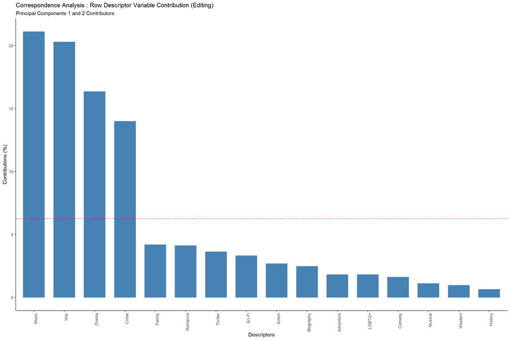

```r
##################################
# Extracting the contribution
# of the row descriptor variables
# for the the Top 1 and 2 principal components
##################################
(DR_CA_Editing_ROW_PCVariableContributors <- fviz_contrib(DR_CA_Editing,
                                                             choice = "row",
                                                             axes = 1:2) +
  labs(title = "Correspondence Analysis : Row Descriptor Variable Contribution (Editing)",
       subtitle = "Principal Components 1 and 2 Contributors",
       x = "Descriptors") +
  theme_classic() +
  theme(axis.text.x = element_text(angle = 90,hjust = 1)))
```

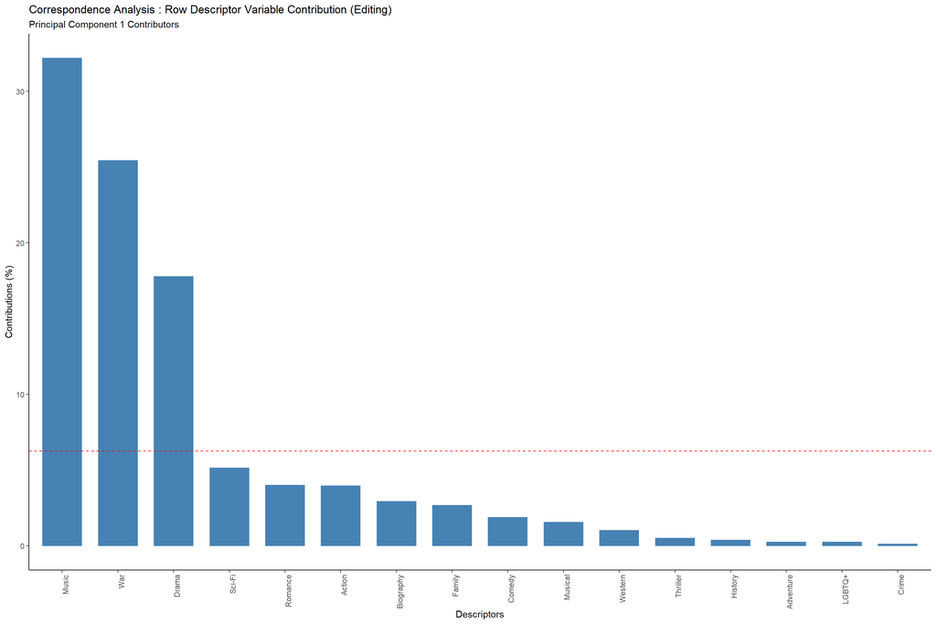

```r
##################################
# Extracting the contribution
# of the row descriptor variables
# for the the Top 1 principal component
##################################
(DR_CA_Editing_ROW_PC1VariableContributors <- fviz_contrib(DR_CA_Editing,
                                                             choice = "row",
                                                             axes = 1) +
  labs(title = "Correspondence Analysis : Row Descriptor Variable Contribution (Editing)",
       subtitle = "Principal Component 1 Contributors",
       x = "Descriptors") +
  theme_classic() +
  theme(axis.text.x = element_text(angle = 90,hjust = 1)))
```

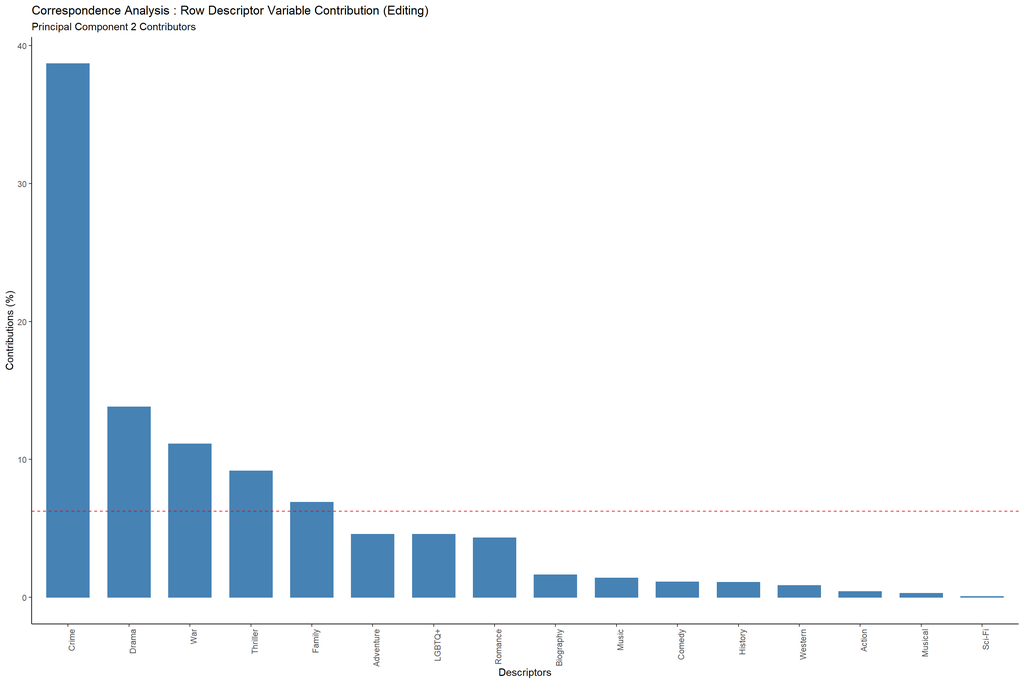

```r
##################################
# Extracting the contribution
# of the row descriptor variables
# for the the Top 2 principal component
##################################
(DR_CA_Editing_ROW_PC2VariableContributors <- fviz_contrib(DR_CA_Editing,
                                                             choice = "row",
                                                             axes = 2) +
  labs(title = "Correspondence Analysis : Row Descriptor Variable Contribution (Editing)",
       subtitle = "Principal Component 2 Contributors",
       x = "Descriptors") +
  theme_classic() +
  theme(axis.text.x = element_text(angle = 90,hjust = 1)))
```

```r
##################################
# Extracting the CA
# results for column descriptor variables
##################################
(DR_CA_Editing_COL <- get_ca_col(DR_CA_Editing))
```

```
## Correspondence Analysis - Results for columns
##  ===================================================
##   Name       Description
## 1 "$coord"   "Coordinates for the columns"
## 2 "$cos2"    "Cos2 for the columns"
## 3 "$contrib" "contributions of the columns"
## 4 "$inertia" "Inertia of the columns"
```

```r
##################################
# Extracting the coordinates
# representing the loadings
# for the column descriptor variabless
##################################
DR_CA_Editing_COL$coord
```

```
##            Dim 1      Dim 2
## NNOM -0.33513143  0.3028233
## NOM   0.04219498 -0.4536803
## WON   1.40375986  0.3937809
```

```r
##################################
# Extracting the quality of representation
# for the column descriptor variables
# on the factor map
##################################
DR_CA_Editing_COL$cos2
```

```
##            Dim 1      Dim 2
## NNOM 0.550513662 0.44948634
## NOM  0.008575927 0.99142407
## WON  0.927049751 0.07295025
```

```r
##################################
# Extracting the contributions
# (in percentage) of the column descriptor variables
# to the principal components
##################################
DR_CA_Editing_COL$contrib
```

```
##           Dim 1    Dim 2
## NNOM 21.0409876 30.54631
## NOM   0.2843353 58.44582
## WON  78.6746771 11.00786
```

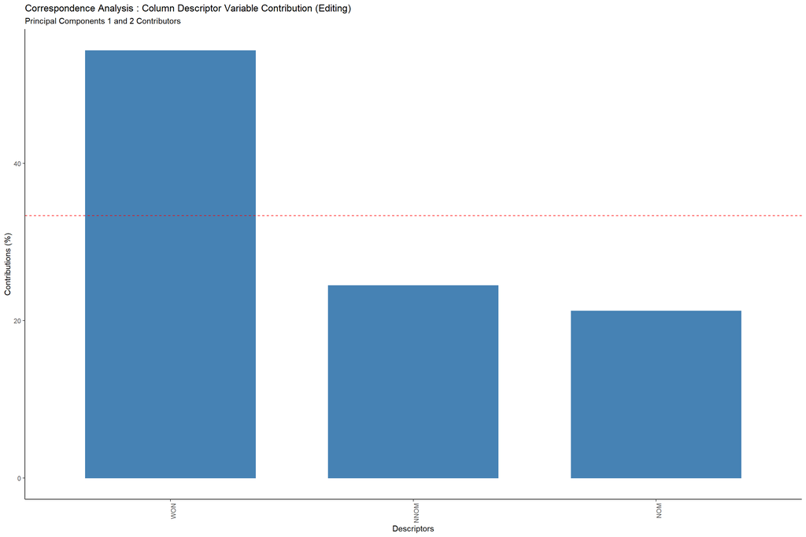

```r
##################################
# Extracting the contribution
# of the column descriptor variables
# for the the Top 1 and 2 principal components
##################################
(DR_CA_Editing_COL_PCVariableContributors <- fviz_contrib(DR_CA_Editing,
                                                             choice = "col",
                                                             axes = 1:2) +
  labs(title = "Correspondence Analysis : Column Descriptor Variable Contribution (Editing)",
       subtitle = "Principal Components 1 and 2 Contributors",
       x = "Descriptors") +
  theme_classic() +
  theme(axis.text.x = element_text(angle = 90,hjust = 1)))
```

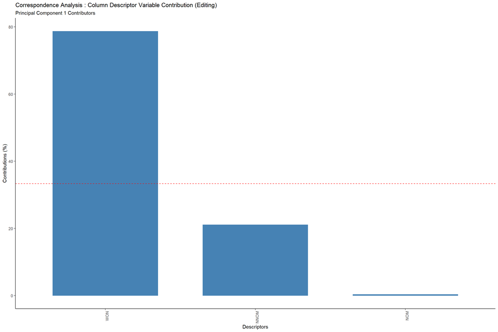

```r
##################################
# Extracting the contribution
# of the column descriptor variables
# for the the Top 1 principal component
##################################
(DR_CA_Editing_COL_PC1VariableContributors <- fviz_contrib(DR_CA_Editing,
                                                             choice = "col",
                                                             axes = 1) +
  labs(title = "Correspondence Analysis : Column Descriptor Variable Contribution (Editing)",
       subtitle = "Principal Component 1 Contributors",
       x = "Descriptors") +
  theme_classic() +
  theme(axis.text.x = element_text(angle = 90,hjust = 1)))
```

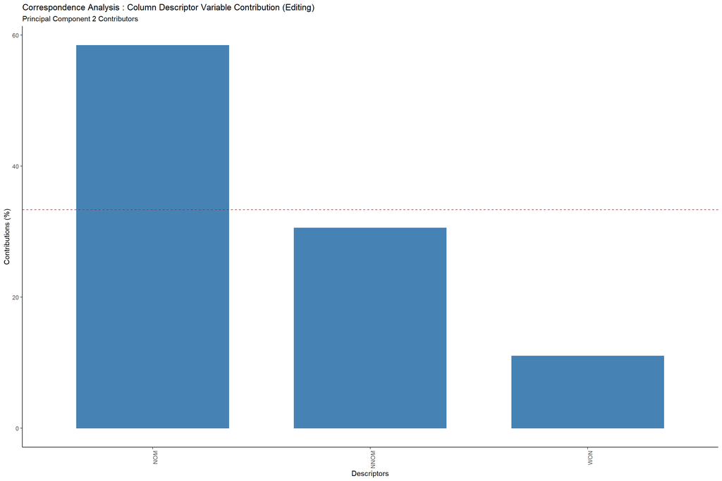

```r
##################################
# Extracting the contribution
# of the column descriptor variables
# for the the Top 2 principal component
##################################
(DR_CA_Editing_COL_PC2VariableContributors <- fviz_contrib(DR_CA_Editing,
                                                             choice = "col",
                                                             axes = 2) +
  labs(title = "Correspondence Analysis : Column Descriptor Variable Contribution (Editing)",
       subtitle = "Principal Component 2 Contributors",
       x = "Descriptors") +
  theme_classic() +
  theme(axis.text.x = element_text(angle = 90,hjust = 1)))
```

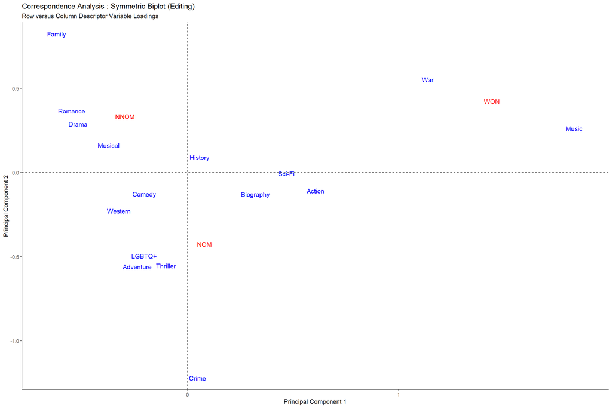

```r
##################################
# Formulating the Symmetric Biplot
# using the row and column
# descriptor variable loadings
# for the Top 1 and Top 2 principal components
##################################
(DR_CA_SymmetricBiplot <- fviz_ca_biplot(DR_CA_Editing,
              label="all",
              geom = "text",
              repel = TRUE) +
  labs(title = "Correspondence Analysis : Symmetric Biplot (Editing)",
       subtitle = "Row versus Column Descriptor Variable Loadings",
       x = "Principal Component 1",
       y = "Principal Component 2") +
  theme_classic())
```

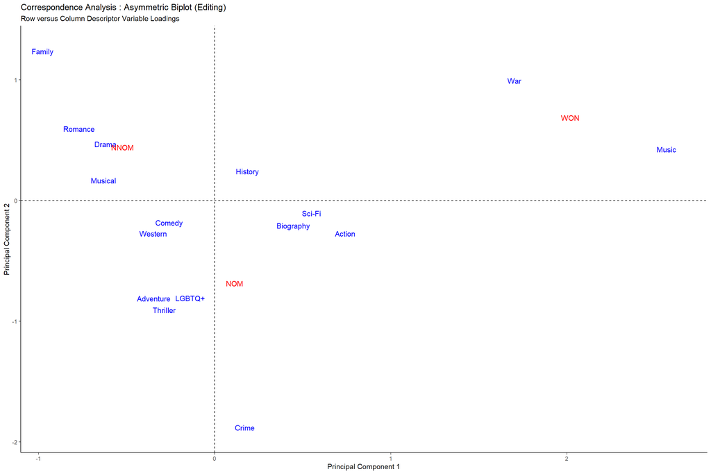

```r
##################################
# Formulating the Asymmetric Biplot
# using the row and column
# descriptor variable loadings
# for the Top 1 and Top 2 principal components
##################################
(DR_CA_SymmetricBiplot <- fviz_ca_biplot(DR_CA_Editing,
              label="all",
              geom = "text",
              repel = TRUE,
              map = "symbiplot") +
  labs(title = "Correspondence Analysis : Asymmetric Biplot (Editing)",
       subtitle = "Row versus Column Descriptor Variable Loadings",
       x = "Principal Component 1",
       y = "Principal Component 2") +
  theme_classic())
```

### 1.5.3 Multiple Correspondence Analysis (MCA)

### 1.5.4 Factor Analysis of Mixed Data (FAMD)

### 1.5.5 Multiple Factor Analysis (MFA)

## 1.6 Algorithm Comparison Summary

# **2. References**

**[Book]** [Applied Predictive Modeling](http://appliedpredictivemodeling.com/) by Max Kuhn and Kjell Johnson  
**[Book]** [An Introduction to Statistical Learning](https://www.statlearning.com/) by Gareth James, Daniela Witten, Trevor Hastie and Rob Tibshirani  
**[Book]** [Multivariate Data Visualization with R](http://lmdvr.r-forge.r-project.org/figures/figures.html) by Deepayan Sarkar  
**[Book]** [Machine Learning](https://bookdown.org/ssjackson300/Machine-Learning-Lecture-Notes/) by Samuel Jackson  
**[Book]** [Data Modeling Methods](https://bookdown.org/larget_jacob/data-modeling-methods/) by Jacob Larget  
**[Book]** [Introduction to R and Statistics](https://saestatsteaching.tech/) by University of Western Australia  
**[Book]** [Feature Engineering and Selection: A Practical Approach for Predictive Models](http://www.feat.engineering/index.html) by Max Kuhn and Kjell Johnson  
**[Book]** [Introduction to Research Methods](https://bookdown.org/ejvanholm/Textbook/) by Eric van Holm  
**[R Package]** [AppliedPredictiveModeling](https://cran.r-project.org/web//packages/AppliedPredictiveModeling/AppliedPredictiveModeling.pdf) by Max Kuhn  
**[R Package]** [caret](https://topepo.github.io/caret/index.html) by Max Kuhn  
**[R Package]** [rpart](https://mran.microsoft.com/web/packages/rpart/rpart.pdf) by Terry Therneau and Beth Atkinson  
**[R Package]** [lattice](https://cran.r-project.org/web/packages/lattice/lattice.pdf) by Deepayan Sarkar  
**[R Package]** [dplyr](https://cran.r-project.org/web/packages/dplyr/index.html/) by Hadley Wickham  
**[R Package]** [moments](https://cran.r-project.org/web/packages/moments/index.html) by Lukasz Komsta and Frederick  
**[R Package]** [skimr](https://cran.r-project.org/web/packages/skimr/skimr.pdf) by Elin Waring  
**[R Package]** [RANN](https://cran.r-project.org/web/packages/RANN/RANN.pdf) by Sunil Arya, David Mount, Samuel Kemp and Gregory Jefferis  
**[R Package]** [corrplot](https://cran.r-project.org/web/packages/corrplot/corrplot.pdf) by Taiyun Wei  
**[R Package]** [tidyverse](https://cran.r-project.org/web/packages/tidyverse/tidyverse.pdf) by Hadley Wickham  
**[R Package]** [lares](https://cran.rstudio.com/web/packages/lares/lares.pdf) by Bernardo Lares  
**[R Package]** [DMwR](https://mran.microsoft.com/snapshot/2016-05-02/web/packages/DMwR/DMwR.pdf) by Luis Torgo  
**[R Package]** [gridExtra](https://cran.r-project.org/web/packages/gridExtra/gridExtra.pdf) by Baptiste Auguie and Anton Antonov  
**[R Package]** [rattle](https://cran.r-project.org/web/packages/rattle/rattle.pdf) by Graham Williams  
**[R Package]** [RColorBrewer](https://cran.r-project.org/web//packages/RColorBrewer/RColorBrewer.pdf) by Erich Neuwirth  
**[R Package]** [stats](https://search.r-project.org/R/refmans/stats/html/00Index.html) by R Core Team  
**[R Package]** [factoextra](https://cran.r-project.org/web/packages/factoextra/factoextra.pdf) by Alboukadel Kassambara and Fabian Mundt  
**[R Package]** [FactoMineR](https://search.r-project.org/R/refmans/stats/html/00Index.html) by Francois Husson, Julie Josse, Sebastien Le and Jeremy Mazet  
**[Article]** [6 Dimensionality Reduction Techniques in R (with Examples)](https://cmdlinetips.com/2022/07/dimensionality-reduction-techniques-in-r/) by CMDLineTips Team  
**[Article]** [6 Dimensionality Reduction Algorithms With Python](https://machinelearningmastery.com/dimensionality-reduction-algorithms-with-python/) by Jason Brownlee  
**[Article]** [Introduction to Dimensionality Reduction for Machine Learning](https://machinelearningmastery.com/dimensionality-reduction-for-machine-learning/) by Jason Brownlee  
**[Article]** [Introduction to Dimensionality Reduction](https://www.geeksforgeeks.org/dimensionality-reduction/) by Geeks For Geeks  
**[Article]** [Principal Component Analysis for Dimensionality Reduction in Python](https://machinelearningmastery.com/principal-components-analysis-for-dimensionality-reduction-in-python/) by Jason Brownlee  
**[Article]** [Principal Component Analysis Explained Simply](https://blog.bioturing.com/2018/06/14/principal-component-analysis-explained-simply/) by Linh Ngo  
**[Article]** [A Step-by-Step Explanation of Principal Component Analysis (PCA)](https://builtin.com/data-science/step-step-explanation-principal-component-analysis) by Zakaria Jaadi  
**[Article]** [What Is Principal Component Analysis (PCA) and How It Is Used?](https://www.sartorius.com/en/knowledge/science-snippets/what-is-principal-component-analysis-pca-and-how-it-is-used-507186) by Sartorius Team  
**[Article]** [Principal Components Analysis](https://online.stat.psu.edu/stat508/book/export/html/639) by by Penn State Eberly College of Science  
**[Article]** [Principal Component Analysis – How PCA Algorithms Works, The Concept, Math and Implementation](https://www.machinelearningplus.com/machine-learning/principal-components-analysis-pca-better-explained/) by Selva Prabhakaran  
**[Publication]** [Analysis of a Complex of Statistical Variables into Principal Components](https://psycnet.apa.org/doiLanding?doi=10.1037%2Fh0071325) by Harold Hotelling (Journal of Educational Psychology)  
**[Course]** [Applied Data Mining and Statistical Learning](https://online.stat.psu.edu/stat508/) by Penn State Eberly College of Science